# Análisis de Datos con R

Diplomado en Análisis de datos con R para la acuicultura.

Francisco Vásquez / franciscojvasqueze@gmail.com

25 de May, 2022

# Análisis Exploratorio de datos de Dosis de Antimicrobianos en la Acuicultura del Salmón.

**1. Importar y transformar datos**

```r
# Importar Excel con datos.

Antimicrobianos <- read_excel("Antimicrobianos_2019_2022.xlsx")

#se aplica Head para una revisión rápido a los datos.
head(Antimicrobianos)
```

```
## # A tibble: 6 × 32
##   idDeclaracion `Tipo Centro de…`   Año Mes   `Código Centro` Nom.Centro Empresa
##           <dbl> <chr>             <dbl> <chr>           <dbl> <chr>      <chr>
## 1       1007396 Agua dulce         2019 Ene             90062 PISCICULT… HENDRI…
## 2       1007396 Agua dulce         2019 Ene             90062 PISCICULT… HENDRI…
## 3       1007396 Agua dulce         2019 Ene             90062 PISCICULT… HENDRI…
## 4       1009386 Agua de mar        2019 Ene            101558 PUMALIN    AQUAGE…
## 5       1006723 Agua de mar        2019 Ene            102013 CALETA SO… CERMAQ…
## 6       1006723 Agua de mar        2019 Ene            102013 CALETA SO… CERMAQ…
## # … with 25 more variables: Holding <chr>, ACS <chr>, Región <chr>,
## #   Especie <chr>, Grupo <chr>, PMV <chr>, Enfermedad <chr>, Estructura <chr>,
## #   Laboratorio <chr>, `Producto Farmacéutico` <chr>, `Principio Activo` <chr>,
## #   `Via de Administración` <chr>, Dosis <dbl>, `Unidad dosis` <chr>,
## #   `Número de Peces` <dbl>, `Peso Promedio (grs)` <dbl>,
## #   `Cantidad de Producto (Kg)` <dbl>, concentracion <dbl>,
## #   `Cantidad de Principio Activo (Kg)` <dbl>, …
```

```r
#Transformar Caracteres en Factor

Antimicrobianos$`Tipo Centro de Cultivo` <- as.factor(Antimicrobianos$`Tipo Centro de Cultivo`)
Antimicrobianos$Año <- as.factor(Antimicrobianos$Año)
Antimicrobianos$Mes <- as.factor(Antimicrobianos$Mes)
Antimicrobianos$`Código Centro` <- as.factor(Antimicrobianos$`Código Centro`)
Antimicrobianos$Nom.Centro <- as.factor(Antimicrobianos$Nom.Centro)
Antimicrobianos$Año <- as.factor(Antimicrobianos$Año)
Antimicrobianos$Empresa <- as.factor(Antimicrobianos$Empresa)
Antimicrobianos$Holding <- as.factor (Antimicrobianos$Holding)
Antimicrobianos$Especie <- as.factor(Antimicrobianos$Especie)
Antimicrobianos$ACS <- as.factor(Antimicrobianos$ACS)
Antimicrobianos$Región <- as.factor(Antimicrobianos$Región)
Antimicrobianos$Grupo <- as.factor(Antimicrobianos$Grupo)
Antimicrobianos$PMV <- as.factor(Antimicrobianos$PMV)
Antimicrobianos$ACS <- as.factor(Antimicrobianos$ACS)
Antimicrobianos$Enfermedad <- as.factor(Antimicrobianos$Enfermedad)
Antimicrobianos$Estructura <- as.factor(Antimicrobianos$Estructura)
Antimicrobianos$Laboratorio <- as.factor(Antimicrobianos$Laboratorio)
Antimicrobianos$`Producto Farmacéutico` <- as.factor(Antimicrobianos$`Producto Farmacéutico`)
Antimicrobianos$`Principio Activo` <- as.factor(Antimicrobianos$`Principio Activo`)
Antimicrobianos$`Via de Administración` <- as.factor (Antimicrobianos$`Via de Administración`)
Antimicrobianos$`Unidad dosis` <- as.factor (Antimicrobianos$`Unidad dosis`)
Antimicrobianos$`Fecha Inicio TTO`<- as.Date(Antimicrobianos$`Fecha Inicio TTO`)
Antimicrobianos$`Fecha Termino TTO` <- as.Date(Antimicrobianos$`Fecha Termino TTO`)
Antimicrobianos$`Planta Elaboradora` <- as.factor (Antimicrobianos$`Planta Elaboradora`)

##Renombrar los niveles de un factor (Especie)para completar datos vacios.

Antimicrobianos<- Antimicrobianos %>%
     mutate(Especie = recode(Especie, "-" = "Salmon rey"))

#Eliminar datos errados de Dosis (Dosis > 1000 mg/kg)

Antimicrobianos <- Antimicrobianos[Antimicrobianos$Dosis < 1000, ]

#Eliminar datos errados de Dosis 2 (Dosis < 1 mg/kg)

Antimicrobianos <- Antimicrobianos[Antimicrobianos$Dosis > 1, ]

#Eliminar datos Nulos de Vía de Administración

Antimicrobianos <- Antimicrobianos[Antimicrobianos$`Via de Administración` != "-", ]

#identificar valor faltante de Holding.

Antimicrobianos %>% filter(Holding == "-") %>% summarize(Empresa)
```

```
## # A tibble: 99 × 1
##    Empresa
##    <fct>
##  1 AQUACHILE SPA
##  2 AQUACHILE SPA
##  3 AQUACHILE SPA
##  4 AQUACHILE SPA
##  5 AQUACHILE SPA
##  6 AQUACHILE SPA
##  7 AQUACHILE SPA
##  8 AQUACHILE SPA
##  9 AQUACHILE SPA
## 10 AQUACHILE SPA
## # … with 89 more rows
```

```r
#Renombrar niveles de un factor (Holding). Se reemplaza el valor por el único valor para Holding = "-", que corresponde a Aquachile.

Antimicrobianos<- Antimicrobianos %>%
     mutate(Holding = recode(Holding, "-" = "EMPRESAS AQUACHILE SA"))

#Renombrar niveles de un factor (Principio Activo). Se reemplazan Principios Activos Eritromicina, tilmicosina, tiamulina y flumequina como otros,, debido a baja cantidad de observaciones.
Antimicrobianos<- Antimicrobianos %>%
     mutate(`Principio Activo` = recode(`Principio Activo`, "ERITROMICINA" = "OTROS"))

Antimicrobianos<- Antimicrobianos %>%
     mutate(`Principio Activo` = recode(`Principio Activo`, "TIAMULINA" = "OTROS"))

Antimicrobianos<- Antimicrobianos %>%
     mutate(`Principio Activo` = recode(`Principio Activo`, "TILMICOSINA" = "OTROS"))

Antimicrobianos<- Antimicrobianos %>%
     mutate(`Principio Activo` = recode(`Principio Activo`, "FLUMEQUINA" = "OTROS"))
```

**1.2 Resumen de datos Usando la función Summary**

```r
summary(Antimicrobianos)
```

```
##  idDeclaracion     Tipo Centro de Cultivo   Año            Mes
##  Min.   :1004608   Agua de mar:9596       2019:2547   Mar    :1971
##  1st Qu.:1144025   Agua dulce :1782       2020:2656   Ene    :1743
##  Median :1274336                          2021:3050   Feb    :1710
##  Mean   :1252861                          2022:3125   May    : 789
##  3rd Qu.:1380838                                      Dic    : 751
##  Max.   :1406913                                      Jul    : 702
##                                                       (Other):3712
##  Código Centro                          Nom.Centro
##  140002 :  338   PISCICULTURA LOS TAMBORES   :  338
##  100650 :  124   QUINTUPEU                   :  124
##  102989 :  100   RUPANQUITO                  :  100
##  110215 :   93   VALVERDE                    :   98
##  102648 :   92   MARCHANT                    :   93
##  110814 :   89   SUR WESTE  ISLA BUTACHAUQUES:   92
##  (Other):10542   (Other)                     :10533
##                                 Empresa
##  SALMONES ANTARTICA S.A.            :1455
##  MOWI CHILE S.A.                    :1044
##  EXPORTADORA LOS FIORDOS LTDA.      : 918
##  SALMONES MULTIEXPORT S.A.          : 770
##  AQUACHILE S.A., EMPRESAS           : 627
##  PRODUCTOS DEL MAR VENTISQUEROS S.A.: 621
##  (Other)                            :5943
##                                 Holding           ACS
##  EMPRESAS AQUACHILE S.A.            :2103   -       :1790
##  SALMONES ANTARTICA S.A             :1455   ACS 2   : 657
##  MOWI CHILE S.A.                    :1044   ACS 17 A: 564
##  MULTIEXPORT FOODS S.A.             : 794   ACS 18 C: 516
##  MARINE FARM                        : 637   ACS 28 B: 503
##  PRODUCTOS DEL MAR VENTISQUEROS S.A.: 621   ACS 1   : 489
##  (Other)                            :4724   (Other) :6859
##                     Región                       Especie
##  ARAUCANIA             : 587   Salmon rey            :   8
##  AYSEN                 :4561   Salmon Del Atlantico  :8084
##  BIO-BIO               : 159   Salmon Plateado O Coho:1272
##  DE LOS RIOS           : 519   Trucha Arcoiris       :2014
##  LOS LAGOS             :4977
##  MAGALLANES Y ANTARTICA: 548
##  MAULE                 :  27
```

[output cut: 41 more lines]

```
##  Min.   :   0.0              Min.   :2010-09-19   Min.   :2019-01-01
##  1st Qu.: 300.0              1st Qu.:2020-01-27   1st Qu.:2020-02-06
##  Median : 300.0              Median :2021-02-12   Median :2021-02-22
##  Mean   : 596.3              Mean   :2020-12-12   Mean   :2020-12-23
##  3rd Qu.: 900.0              3rd Qu.:2021-12-26   3rd Qu.:2022-01-13
##  Max.   :3200.0              Max.   :2022-04-01   Max.   :2022-04-01
##
##  Duración tratamiento       T°                        Planta Elaboradora
##  Min.   :   0.00      Min.   : 4.9   No aplica                 :3263
##  1st Qu.:   2.00      1st Qu.:10.8   Skretting                 :2036
##  Median :  12.00      Median :12.0   Pesquera Los Fiordos Ltda.:1677
##  Mean   :  11.63      Mean   :12.1   Biomar (Alitec)           :1639
##  3rd Qu.:  17.00      3rd Qu.:13.1   Ewos Chile Alimentos Ltda.: 919
##  Max.   :3653.00      Max.   :21.1   Salmofood                 : 867
##                                      (Other)                   : 977
```

**2. Tablas resumen de los factores a evaluar.**

Se realizan tablas resumen de los diferentes factores a evaluar en relación a la dosis (Principio Activo, Vía de Administración, Enfermedad, tipo centro de cultivo, Holding). Los datos han sido filtrados al año 2021 por ser el año a considerar para el siguiente análisis.

```r
knitr::opts_chunk$set(warning = FALSE, message = FALSE)

# Principio Activo.
Antimicrobianos %>% filter(Año == "2021") %>%group_by(`Principio Activo`) %>%summarize("N" = n(),
                                                               "Promedio" = mean(Dosis),
                                                               "Mediana" = median(Dosis),
                                                               "Máximo" = max(Dosis),
                                                               "Mínimo" = min(Dosis))
```

```
## # A tibble: 3 × 6
##   `Principio Activo`     N Promedio Mediana Máximo Mínimo
##   <fct>              <int>    <dbl>   <dbl>  <dbl>  <dbl>
## 1 OTROS                 47     23.7    12.1    100     10
## 2 FLORFENICOL         1993     19.2    20       40     10
## 3 OXITETRACICLINA     1010     36.5    30      125     20
```

```r
# Principio activo por vía de administración.
Antimicrobianos %>% filter(Año == "2021") %>%  group_by(`Principio Activo`, `Via de Administración`) %>%
  summarize("N" = n(), "Promedio" = mean(Dosis),
                       "Mediana" = median(Dosis),
                       "Máximo" = max(Dosis),
                       "Mínimo" = min(Dosis))
```

```
## # A tibble: 7 × 7
## # Groups:   Principio Activo [3]
##   `Principio Activo` `Via de Administraci…`     N Promedio Mediana Máximo Mínimo
##   <fct>              <fct>                  <int>    <dbl>   <dbl>  <dbl>  <dbl>
## 1 OTROS              Oral                      47     23.7    12.1  100       10
## 2 FLORFENICOL        Inmersión                  8     17.5    20     20.1     10
## 3 FLORFENICOL        Inyectable                77     33.6    30     40       20
## 4 FLORFENICOL        Oral                    1908     18.6    20     33.9     10
## 5 OXITETRACICLINA    Inmersión                 22    104.    100    125       80
## 6 OXITETRACICLINA    Inyectable               902     29.2    28     40       20
## 7 OXITETRACICLINA    Oral                      86     95.8   100.   102.      75
```

```r
# Principio activo por enfermedad según vía de administración.
Antimicrobianos %>% filter(Año == "2021") %>%  group_by(`Principio Activo`, `Via de Administración`, Enfermedad) %>% summarize("N" = n(),
                                                               "Promedio" = mean(Dosis),
                                                               "Mediana" = median(Dosis),
                                                               "Máximo" = max(Dosis),
                                                               "Mínimo" = min(Dosis))
```

[output not shown]

```
## # A tibble: 26 × 8
## # Groups:   Principio Activo, Via de Administración [7]
##    `Principio Activo` `Via de Adminis…` Enfermedad     N Promedio Mediana Máximo
##    <fct>              <fct>             <fct>      <int>    <dbl>   <dbl>  <dbl>
##  1 OTROS              Oral              Piscirick…     1     12.1    12.1   12.1
##  2 OTROS              Oral              Renibacte…    23     36.2    10    100
##  3 OTROS              Oral              Tenacibac…    23     11.8    12.1   12.5
##  4 FLORFENICOL        Inmersión         Flavobact…     7     17.2    20     20.1
##  5 FLORFENICOL        Inmersión         Renibacte…     1     20      20     20
##  6 FLORFENICOL        Inyectable        Piscirick…    72     33.8    30     40
##  7 FLORFENICOL        Inyectable        Renibacte…     2     30      30     30
##  8 FLORFENICOL        Inyectable        Tenacibac…     3     33.3    35     35
##  9 FLORFENICOL        Oral              Enfermeda…     5     20      20     20
## 10 FLORFENICOL        Oral              Flavobact…   450     19.9    20     30
## # … with 16 more rows, and 1 more variable: Mínimo <dbl>
```

```r
# Principio activo por especie según vía de administración.
Antimicrobianos %>% filter(Año == "2021") %>%  group_by(`Principio Activo`, Especie, `Via de Administración`) %>% summarize("N" = n(),
                                                               "Promedio" = mean(Dosis),
                                                               "Mediana" = median(Dosis),
                                                               "Máximo" = max(Dosis),
                                                               "Mínimo" = min(Dosis))
```

```
## # A tibble: 22 × 8
## # Groups:   Principio Activo, Especie [9]
##    `Principio Activo` Especie     `Via de Admini…`     N Promedio Mediana Máximo
##    <fct>              <fct>       <fct>            <int>    <dbl>   <dbl>  <dbl>
##  1 OTROS              Salmon Del… Oral                44     24.7    12.1  100
##  2 OTROS              Salmon Pla… Oral                 3     10      10     10
##  3 FLORFENICOL        Salmon Del… Inmersión            6     16.7    20     20
##  4 FLORFENICOL        Salmon Del… Inyectable          30     29.3    30     35
##  5 FLORFENICOL        Salmon Del… Oral              1486     18.2    20     33.9
##  6 FLORFENICOL        Salmon Pla… Inmersión            1     20.1    20.1   20.1
##  7 FLORFENICOL        Salmon Pla… Inyectable          44     36.6    40     40
##  8 FLORFENICOL        Salmon Pla… Oral               118     20.3    20     30
##  9 FLORFENICOL        Trucha Arc… Inmersión            1     20      20     20
## 10 FLORFENICOL        Trucha Arc… Inyectable           3     33.3    35     35
## # … with 12 more rows, and 1 more variable: Mínimo <dbl>
```

```r
# Principio activo por Empresa (Holding) según vía de administración.
Antimicrobianos %>% filter(Año == "2021") %>%  group_by(`Principio Activo`, `Via de Administración`, Holding) %>%  arrange(`Principio Activo`) %>% summarize("N" = n(), "Promedio" = mean(Dosis),
                      "Mediana" = median(Dosis),
                    "Máximo" = max(Dosis),
                     "Mínimo" = min(Dosis))
```

[output not shown]

```
## # A tibble: 102 × 8
## # Groups:   Principio Activo, Via de Administración [7]
##    `Principio Activo` `Via de Administra…` Holding     N Promedio Mediana Máximo
##    <fct>              <fct>                <fct>   <int>    <dbl>   <dbl>  <dbl>
##  1 OTROS              Oral                 EMPRES…     1     12.1    12.1   12.1
##  2 OTROS              Oral                 EMPRES…    41     15.2    12.1  100
##  3 OTROS              Oral                 PISCIC…     3    100     100    100
##  4 OTROS              Oral                 TROUTL…     2     90      90    100
##  5 FLORFENICOL        Inmersión            AUSTRA…     2     20      20     20
##  6 FLORFENICOL        Inmersión            BURGEM…     2     20      20     20
##  7 FLORFENICOL        Inmersión            PISCIC…     2     10      10     10
##  8 FLORFENICOL        Inmersión            SALMON…     1     20      20     20
##  9 FLORFENICOL        Inmersión            SALMON…     1     20.1    20.1   20.1
## 10 FLORFENICOL        Inyectable           AQUAGE…     3     30      30     30
## # … with 92 more rows, and 1 more variable: Mínimo <dbl>
```

**3. Descripción de las diferentes variables utilizando histogramas.**

**3.1 Dosis por Principio Activo**

Se tomará el análisis del año 2021.

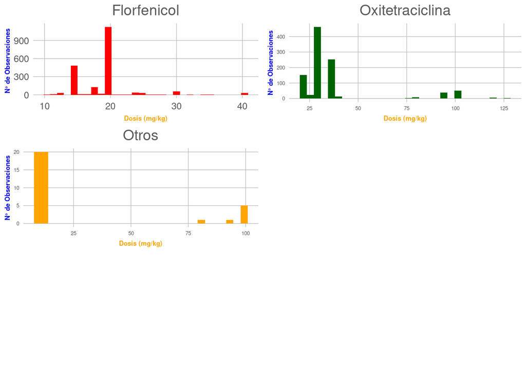

```r
# Dosis por Principio Activo

#Florfenicol
hist_ff <- Antimicrobianos  %>% filter(Año == "2021", `Principio Activo`=="FLORFENICOL") %>%  ggplot(aes(x=Dosis)) + geom_histogram(bins=30, fill = "red") + labs(x = "Dosis (mg/kg)", y = "N° de Observaciones") + ggtitle("Florfenicol") + theme(axis.text = element_text(size = 5))+theme_excel_new()+ theme(axis.title.x = element_text(face="bold", vjust=-0.25, colour="orange", size=rel(0.7))) +
    theme(axis.title.y = element_text(face="bold", vjust=1, colour="blue", size=rel(0.7)))

#Oxitetraciclina
hist_otc <-Antimicrobianos  %>% filter(Año == "2021", `Principio Activo`=="OXITETRACICLINA") %>%  ggplot(aes(x=Dosis)) + geom_histogram(bins = 30, fill = "darkgreen")+labs(title = "Oxitetraciclina", x = "Dosis (mg/kg)", y = "N° de Observaciones") + theme_excel_new()+ggtitle("Oxitetraciclina") + theme(axis.text = element_text(size = 5))+ theme(axis.title.x = element_text(face="bold", vjust=-0.25, colour="orange", size=rel(0.7))) +
    theme(axis.title.y = element_text(face="bold", vjust=1, colour="blue", size=rel(0.7)))

#OTROS
hist_otros <-Antimicrobianos  %>% filter(Año == "2021", `Principio Activo`=="OTROS") %>%  ggplot(aes(x=Dosis)) + geom_histogram(bins = 30, fill = "orange")+labs(title = "Otros", x = "Dosis (mg/kg)", y = "N° de Observaciones") + theme_excel_new()+ggtitle("Otros") + theme(axis.text = element_text(size = 5))+ theme(axis.title.x = element_text(face="bold", vjust=-0.25, colour="orange", size=rel(0.7))) +
    theme(axis.title.y = element_text(face="bold", vjust=1, colour="blue", size=rel(0.7)))



grid.arrange(hist_ff, hist_otc,hist_otros , ncol = 2, nrow = 3)
```

**3.2 Dosis por Vía de Administración y principio Activo**

En esta sección se analizará La dosis según vía de Administración, para los principios Activos Florfenicol y Oxitetraciclina, ya que todos los otros principios activos sólo se dan vía Oral

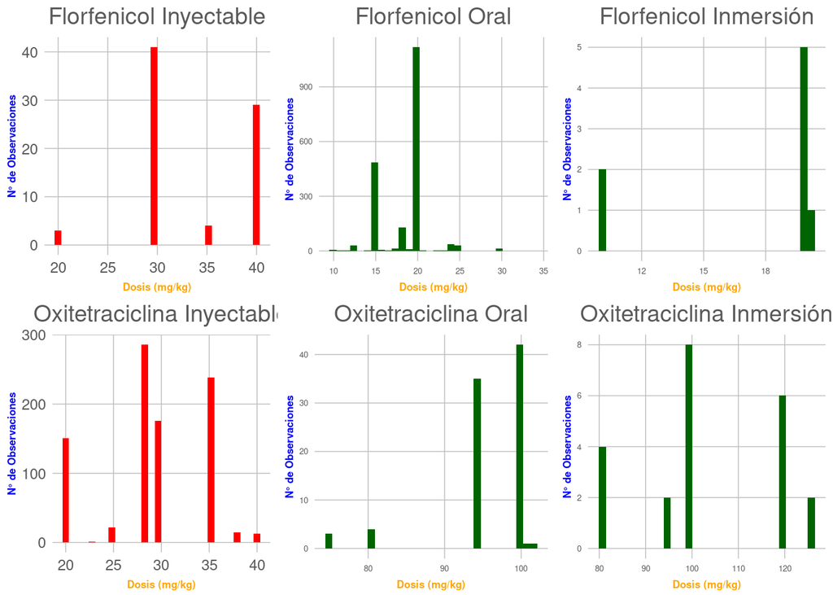

```r
# Dosis Florfenicol, vía de administración Inyectable:

hist_FFC_Iny <- Antimicrobianos  %>% filter(Año == "2021", `Via de Administración`=="Inyectable", `Principio Activo`== "FLORFENICOL") %>%  ggplot(aes(x=Dosis)) + geom_histogram(bins=30, fill = "red") + labs(x = "Dosis (mg/kg)", y = "N° de Observaciones") + ggtitle("Florfenicol Inyectable") + theme(axis.text = element_text(size = 5))+theme_excel_new()+ theme(axis.title.x = element_text(face="bold", vjust=-0.25, colour="orange", size=rel(0.7))) +
    theme(axis.title.y = element_text(face="bold", vjust=1, colour="blue", size=rel(0.7)))

## Dosis Florfenicol, vía de administración Oral:
hist_FFC_O <-Antimicrobianos  %>% filter(Año == "2021", `Via de Administración`=="Oral", `Principio Activo`=="FLORFENICOL") %>%  ggplot(aes(x=Dosis)) + geom_histogram(bins = 30, fill = "darkgreen")+labs(title = "Florfenicol", x = "Dosis (mg/kg)", y = "N° de Observaciones") + theme_excel_new()+ggtitle("Florfenicol Oral") + theme(axis.text = element_text(size = 5))+ theme(axis.title.x = element_text(face="bold", vjust=-0.25, colour="orange", size=rel(0.7))) +
    theme(axis.title.y = element_text(face="bold", vjust=1, colour="blue", size=rel(0.7)))

#Dosis Florfenicol, vía de administración Inmersión
hist_FFC_Inm <-Antimicrobianos  %>% filter(Año == "2021", `Via de Administración`=="Inmersión", `Principio Activo`=="FLORFENICOL") %>%  ggplot(aes(x=Dosis)) + geom_histogram(bins = 30, fill = "darkgreen")+labs(title = "Florfenicol", x = "Dosis (mg/kg)", y = "N° de Observaciones") + theme_excel_new()+ggtitle("Florfenicol Inmersión") + theme(axis.text = element_text(size = 5))+ theme(axis.title.x = element_text(face="bold", vjust=-0.25, colour="orange", size=rel(0.7))) +
    theme(axis.title.y = element_text(face="bold", vjust=1, colour="blue", size=rel(0.7)))


# Dosis Oxitetraciclina, vía de administración Inyectable:

hist_OTC_Iny <- Antimicrobianos  %>% filter(Año == "2021", `Via de Administración`=="Inyectable", `Principio Activo`== "OXITETRACICLINA") %>%  ggplot(aes(x=Dosis)) + geom_histogram(bins=30, fill = "red") + labs(x = "Dosis (mg/kg)", y = "N° de Observaciones") + ggtitle("Oxitetraciclina Inyectable") + theme(axis.text = element_text(size = 5))+theme_excel_new()+ theme(axis.title.x = element_text(face="bold", vjust=-0.25, colour="orange", size=rel(0.7))) +
    theme(axis.title.y = element_text(face="bold", vjust=1, colour="blue", size=rel(0.7)))

## Dosis Oxitetraciclina, vía de administración Oral:
hist_OTC_O <-Antimicrobianos  %>% filter(Año == "2021", `Via de Administración`=="Oral", `Principio Activo`=="OXITETRACICLINA") %>%  ggplot(aes(x=Dosis)) + geom_histogram(bins = 30, fill = "darkgreen")+labs(title = "Oxitetraciclina Oral", x = "Dosis (mg/kg)", y = "N° de Observaciones") + theme_excel_new()+ggtitle("Oxitetraciclina Oral") + theme(axis.text = element_text(size = 5))+ theme(axis.title.x = element_text(face="bold", vjust=-0.25, colour="orange", size=rel(0.7))) +
    theme(axis.title.y = element_text(face="bold", vjust=1, colour="blue", size=rel(0.7)))

#Dosis Florfenicol, vía de administración Inmersión
hist_OTC_Inm <-Antimicrobianos  %>% filter(Año == "2021", `Via de Administración`=="Inmersión", `Principio Activo`=="OXITETRACICLINA") %>%  ggplot(aes(x=Dosis)) + geom_histogram(bins = 30, fill = "darkgreen")+labs(title = "Oxitetraciclina Inmersión", x = "Dosis (mg/kg)", y = "N° de Observaciones") + theme_excel_new()+ggtitle("Oxitetraciclina Inmersión") + theme(axis.text = element_text(size = 5))+ theme(axis.title.x = element_text(face="bold", vjust=-0.25, colour="orange", size=rel(0.7))) +
    theme(axis.title.y = element_text(face="bold", vjust=1, colour="blue", size=rel(0.7)))

grid.arrange(hist_FFC_Iny, hist_FFC_O, hist_FFC_Inm, hist_OTC_Iny, hist_OTC_O, hist_OTC_Inm, ncol = 3, nrow = 2)
```

- Observación N° 1: Se puede apreciar la diferencia de dosis utilizadas en Oxitetraciclina Entre las dosis Orales/inmersión, en relación a las Dosis Inyectables, las cuales se distribuyen en un rango mas bajo de dosis.
- Observación N° 2: Sólo la Dosis en Florfenicol Oral parteciera tener una distribución Normal.

**3.3. Dosis por principio activo en detalle.**

**3.3.1. Dosis Florfenicol**

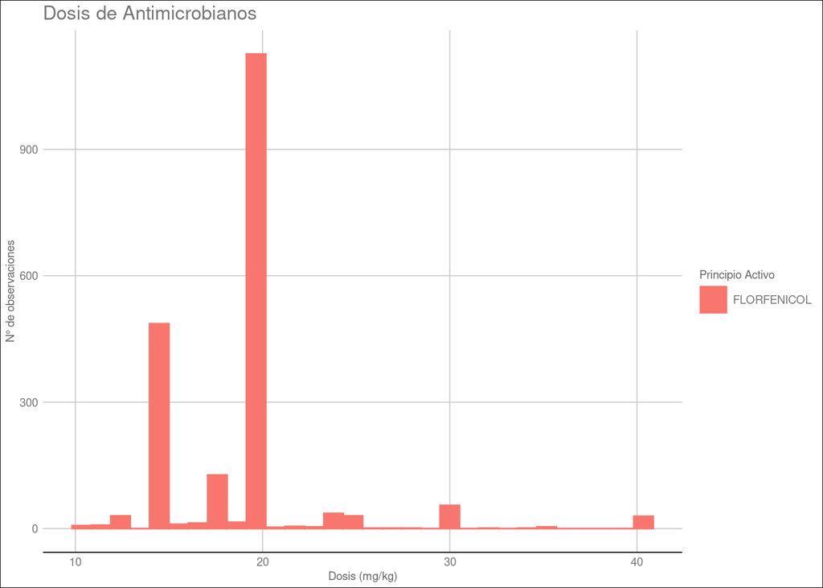

```r
# Dosis Florfenicol

Antimicrobianos%>% filter(Año == "2021", `Principio Activo` == "FLORFENICOL") %>%  ggplot(aes(x=Dosis, color = `Principio Activo`, fill = `Principio Activo`)) + geom_histogram(bins = 30)+labs(title = "Dosis de Antimicrobianos",, x = "Dosis (mg/kg)", y = "N° de observaciones") + theme_gdocs(base_size = 7)
```

- Observación N°1: La mayoría de las dosis utilizadas corresponde a 15 y 20 mg/kg.
- Observación N°2: La mayoría de los datos pareciera distribuir normal.

**3.3.2. Dosis Oxitetraciclina**

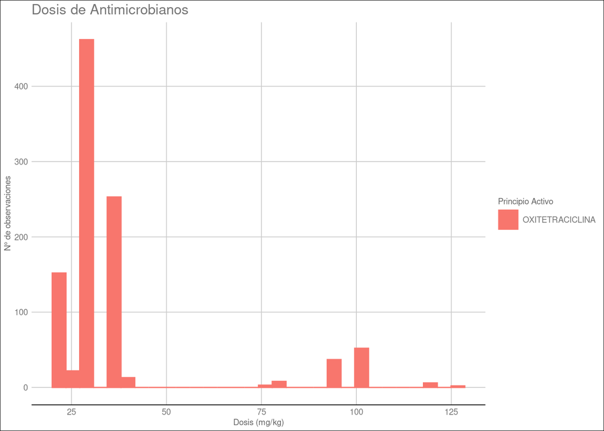

```r
# Dosis Oxitetraciclina

Antimicrobianos%>% filter(Año == "2021", `Principio Activo` == "OXITETRACICLINA") %>%  ggplot(aes(x=Dosis, color = `Principio Activo`, fill = `Principio Activo`)) + geom_histogram(bins = 30)+labs(title = "Dosis de Antimicrobianos", x = "Dosis (mg/kg)", y = "N° de observaciones") + theme_gdocs(base_size = 7)
```

**3.3.3. Dosis Otros**

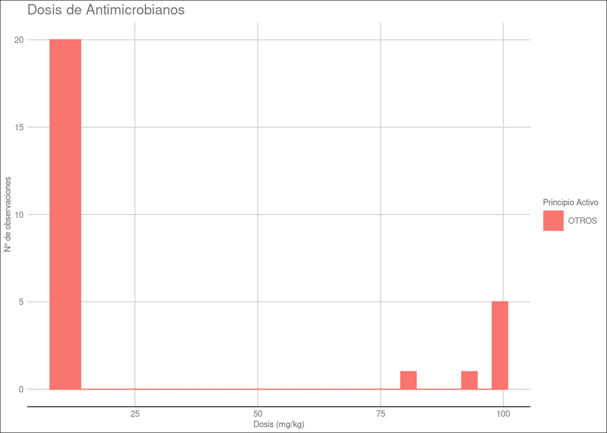

```r
# Dosis Eritromicina

Antimicrobianos%>% filter(Año == "2021", `Principio Activo` == "OTROS") %>%  ggplot(aes(x=Dosis, color = `Principio Activo`, fill= `Principio Activo`)) + geom_histogram(bins = 30) + labs(title = "Dosis de Antimicrobianos ", x = "Dosis (mg/kg)", y = "N° de observaciones") + theme_gdocs(base_size = 7)
```

- Observación N°1: Se aprecia un bajo volumen de observaciones, con valores muy alineados a la izquierda,y un grupo menor de valores a la derech, que corresponderían a diferentes dosis de lso principios activos agrupados.

**4. Establecer Relación Entre la variable dosis y principio activo, de acuerdo a los factores a analizar.**

**4.1. Dosis por principio activo por especie, según diferentes vías de Administración.**

Se agrupan por vías de Administración ya que se observó como en Oxitetraciclina la vía de Administración afecta los valores de dosis.

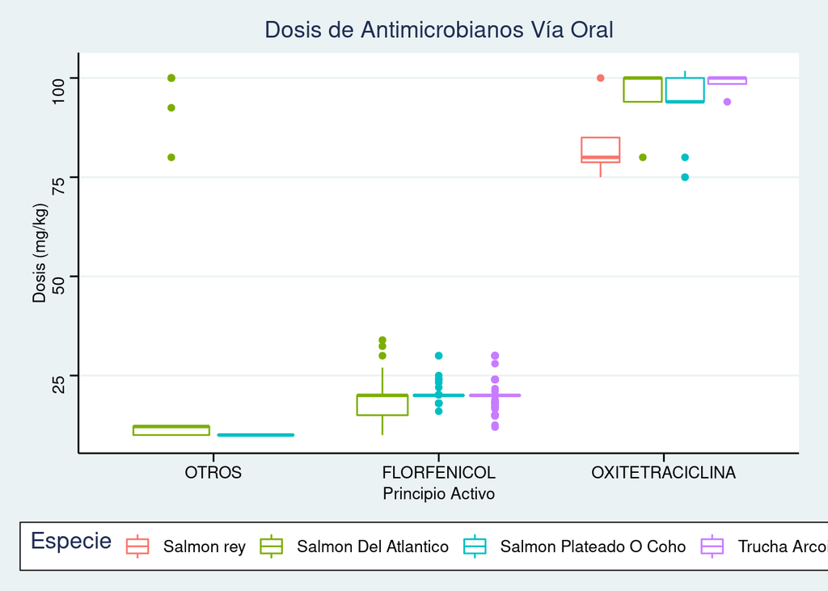

```r
# Dosis por principio activo por especie, según diferentes vías de Administración.

Antimicrobianos %>% filter(Año == "2021", `Via de Administración`== "Oral") %>% group_by(`Via de Administración`) %>% ggplot(aes(x = `Principio Activo`, y = Dosis, color = Especie)) + geom_boxplot()+labs(title = "Dosis de Antimicrobianos Vía Oral", x = "Principio Activo", y = "Dosis (mg/kg)") + theme_stata()
```

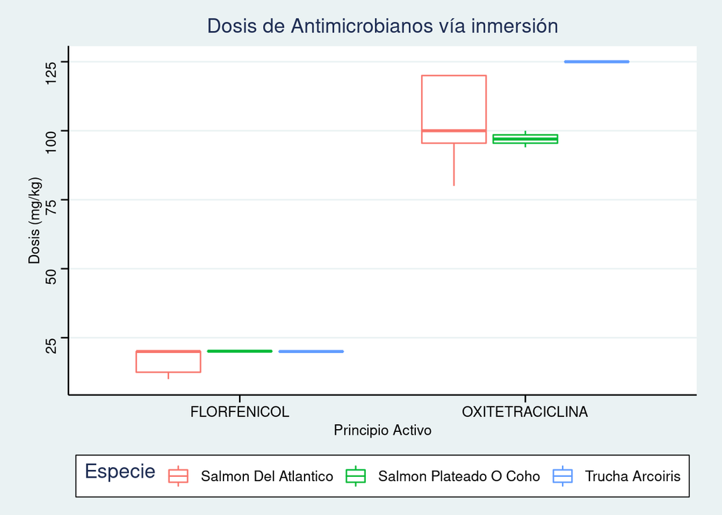

```r
Antimicrobianos %>% filter(Año == "2021", `Via de Administración`== "Inmersión") %>% group_by(`Via de Administración`) %>% ggplot(aes(x = `Principio Activo`, y = Dosis, color = Especie)) + geom_boxplot()+labs(title = "Dosis de Antimicrobianos vía inmersión", x = "Principio Activo", y = "Dosis (mg/kg)") + theme_stata()
```

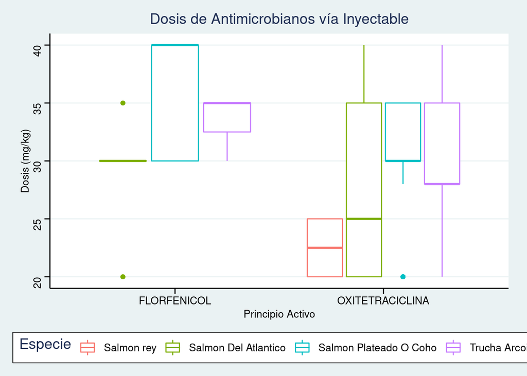

```r
Antimicrobianos %>% filter(Año == "2021", `Via de Administración`== "Inyectable") %>% group_by(`Via de Administración`) %>% ggplot(aes(x = `Principio Activo`, y = Dosis, color = Especie)) + geom_boxplot()+labs(title = "Dosis de Antimicrobianos vía Inyectable", x = "Principio Activo", y = "Dosis (mg/kg)") + theme_stata()
```

-Observación N°1: Los Antimicrobianos entragdos por vía oral son la principal fuente de observacioens de este análisis. Respecto de Flofenicol, su dispersión es entre los 10 y los 35 mg/kg, concentrandose principalmente a 20 mg/kg en todas las especies. - Observación N° 2: Oxitetraciclina por su parte presenta una mayor dispersión de sus datos, de manera distinta para cada especie, donde destacan las dosis menores de Salmón Rey y Salmón Coho. Respecto a Salmón del Atlántico, destaca la concentración de su mediana a los 100 mg/kg, siendo que los fámacos orales de Oxitetraciclina estan registrados a 75 mg/kg. Lo mismo para salmón Coho y Trucha arcoíris, aunque corresponden a un número menor de observaciones.

- Observación N°3: Respecto al uso por inmersón llama la atención el uso de oxitetraciclina vía inmersión ya que no hay productos registrados en salmónidos para esta vía.
- Observación N°4: Respecto de la vía inyectable llama la atención la diferencia de las medianaspara cada especie, sobretodo en Oxitetraciclina, considerando que es la vía de elección para este principio activo.

**4.2. Dosis por principio activo por Enfermedad, según diferentes vías de Administración.**

Se agrupan por vías de Administración ya que se observó como en Oxitetraciclina la vía de Administración afecta los valores de dosis, por su menor biodisponibilidad oral.

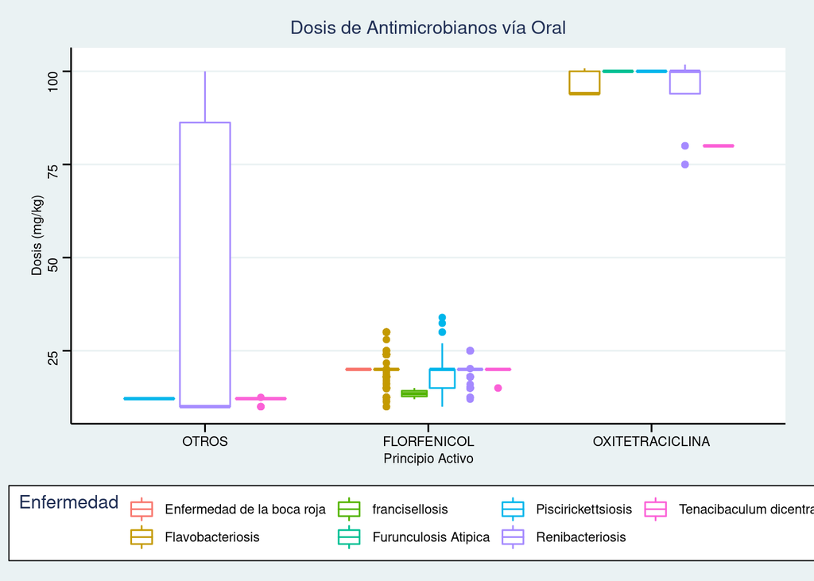

```r
# Dosis por principio activo por Enfermedad.

Antimicrobianos %>% filter(Año == "2021", `Via de Administración`== "Oral") %>% group_by(`Via de Administración`) %>% ggplot(aes(x = `Principio Activo`, y = Dosis, color = Enfermedad)) + geom_boxplot()+labs(title = "Dosis de Antimicrobianos vía Oral", x = "Principio Activo", y = "Dosis (mg/kg)") + theme_stata(base_size = 9)
```

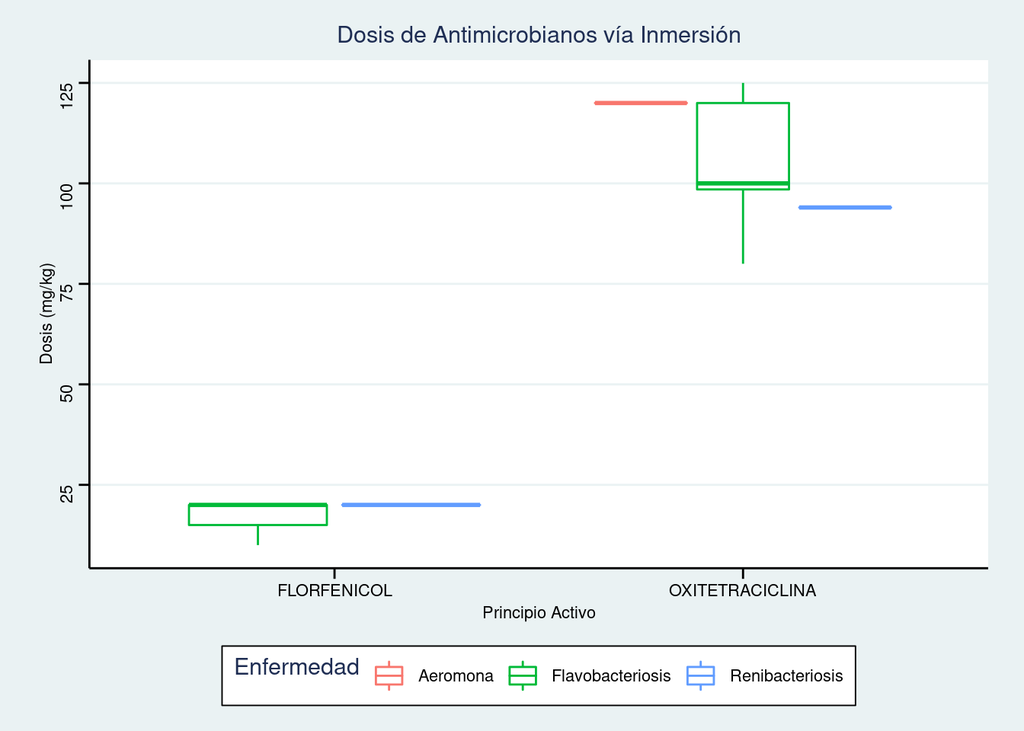

```r
Antimicrobianos %>% filter(Año == "2021", `Via de Administración`== "Inmersión") %>% group_by(`Via de Administración`) %>% ggplot(aes(x = `Principio Activo`, y = Dosis, color = Enfermedad)) + geom_boxplot()+labs(title = "Dosis de Antimicrobianos vía Inmersión", x = "Principio Activo", y = "Dosis (mg/kg)") + theme_stata(base_size = 9)
```

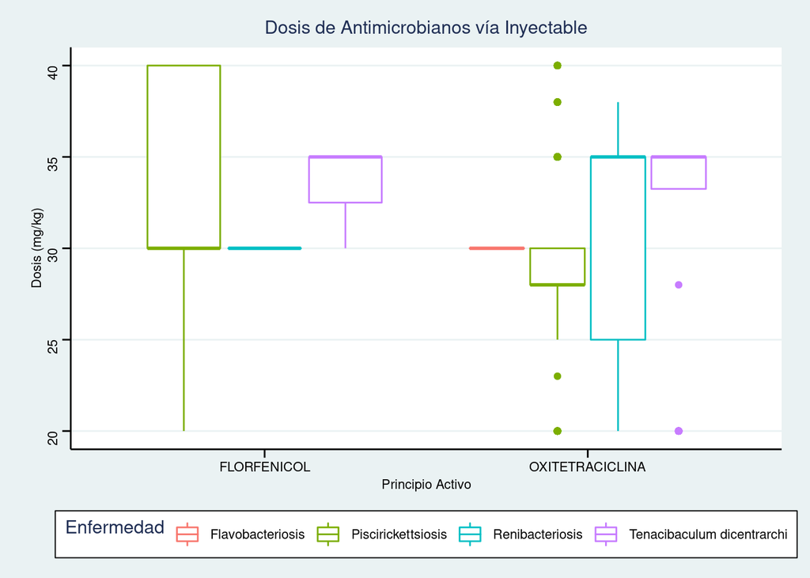

```r
Antimicrobianos %>% filter(Año == "2021", `Via de Administración`== "Inyectable") %>% group_by(`Via de Administración`) %>% ggplot(aes(x = `Principio Activo`, y = Dosis, color = Enfermedad)) + geom_boxplot()+labs(title = "Dosis de Antimicrobianos vía Inyectable", x = "Principio Activo", y = "Dosis (mg/kg)") + theme_stata(base_size = 9)
```

- Observación N° 1: Respecto a los antimicrobianos por vía oral llama la atención que dos principios activos seán utilizado practicamente para todas las enfermedades en salmónidos.
- Observación N° 2:Florfenicol tiene un amplio uso en Flavobacteriosis, Francicelosis, SRS, BKD y Tenacibaculosis. Destaca la homogeneidad de las medianas, todas sobre el valor de dosis registrado (10 mg/kg).
- Observación N°3:De los antimicrobianos entragdos por vía de Inmersión sólo estan presentes Florfenicol y Oxitetraciclina, los cuales son utilizados principalemnte para patologías de Agua Dulce como se puede observar.
- Observación N° 4: Respecto de la vía inyectable, destacan los valores outliers de Oxitetraciclina contra SRS, que pudieran ser errores de reporte, y la dispersión en el tratamiento de BKD, donde es antibiotico de elección.

**4.3. Dosis por principio activo por Holding, según diferentes vías de Administración.**

Se agrupan por vías de Administración ya que se observó como en Oxitetraciclina la vía de Administración afecta los valores de dosis, por su menor biodisponibilidad oral.

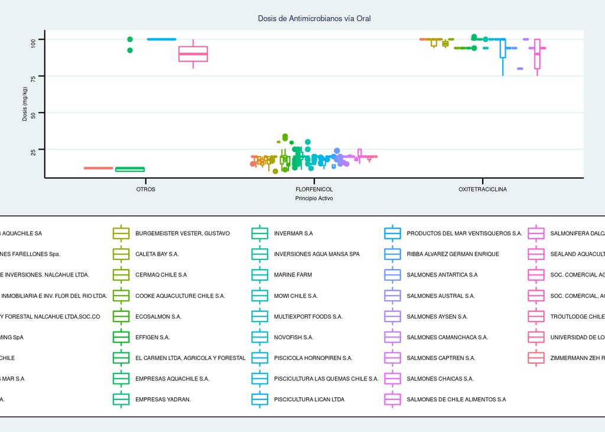

```r
# Dosis por principio activo por Holding.

Antimicrobianos %>% filter(Año == "2021", `Via de Administración`== "Oral") %>% group_by(`Via de Administración`) %>% ggplot(aes(x = `Principio Activo`, y = Dosis, color = Holding)) + geom_boxplot()+labs(title = "Dosis de Antimicrobianos vía Oral", x = "Principio Activo", y = "Dosis (mg/kg)") + theme_stata(base_size = 5)
```

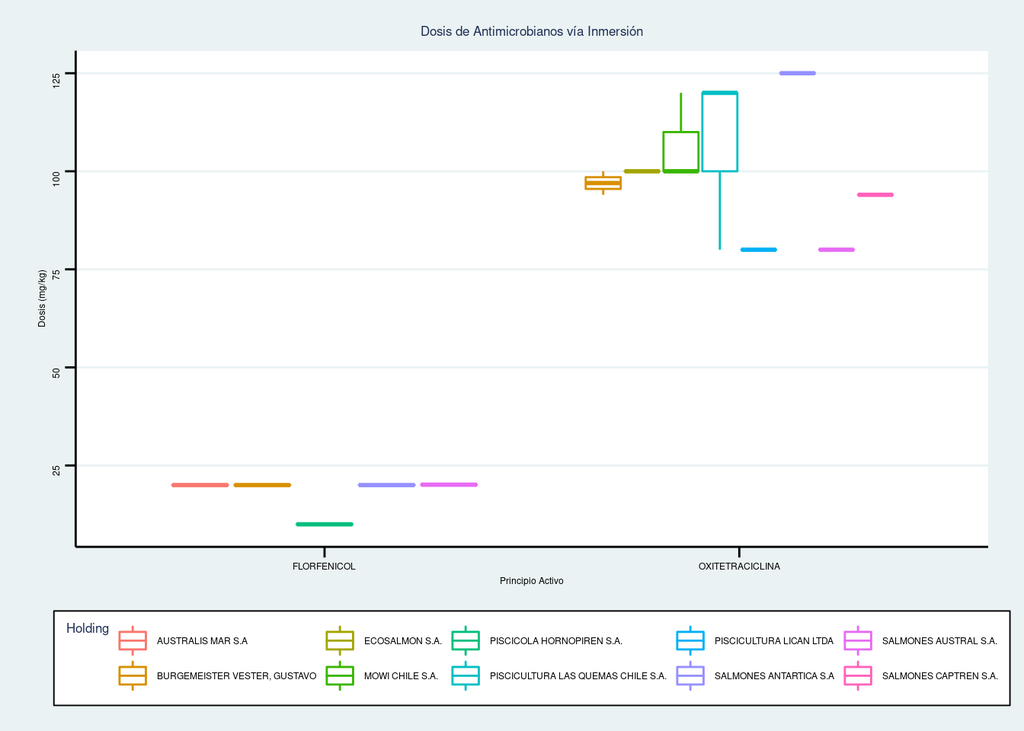

```r
Antimicrobianos %>% filter(Año == "2021", `Via de Administración`== "Inmersión") %>% group_by(`Via de Administración`) %>% ggplot(aes(x = `Principio Activo`, y = Dosis, color = Holding)) + geom_boxplot()+labs(title = "Dosis de Antimicrobianos vía Inmersión", x = "Principio Activo", y = "Dosis (mg/kg)") + theme_stata(base_size = 5)
```

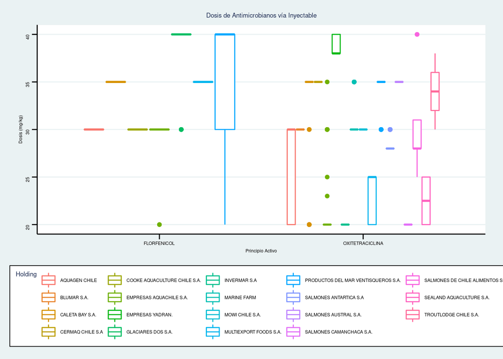

```r
Antimicrobianos %>% filter(Año == "2021", `Via de Administración`== "Inyectable") %>% group_by(`Via de Administración`) %>% ggplot(aes(x = `Principio Activo`, y = Dosis, color = Holding)) + geom_boxplot()+labs(title = "Dosis de Antimicrobianos vía Inyectable", x = "Principio Activo", y = "Dosis (mg/kg)") + theme_stata(base_size = 5)
```

**Graficos de Tamaños de los efectos**

Se realizá Gráfica del tamaño de los efectos para los diferentes factores a evaluar en función de la dosis.

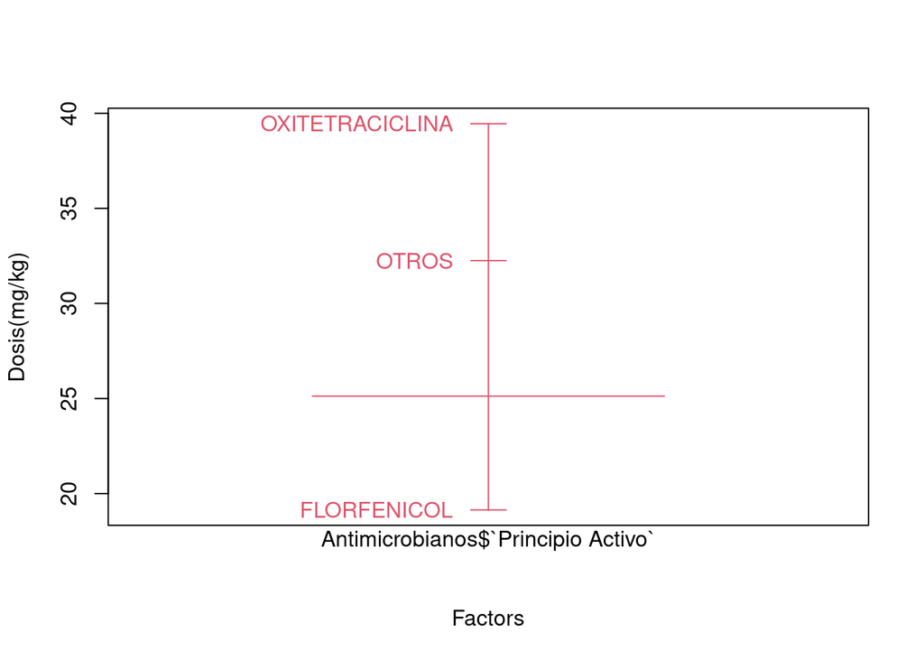

```r
opts_chunk$set(warning = FALSE, message = FALSE)

# Gráfica de tamaño de los efectos

plot.design(Antimicrobianos$Dosis ~Antimicrobianos$`Principio Activo`, col=2,  ylab = "Dosis(mg/kg)")
```

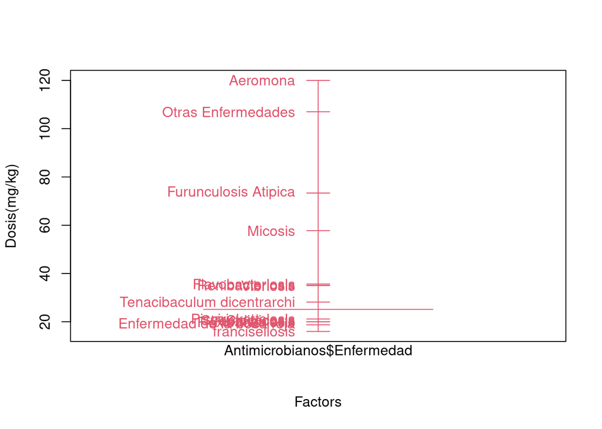

```r
plot.design(Antimicrobianos$Dosis ~ Antimicrobianos$Enfermedad, col=2, ylab = "Dosis(mg/kg)")
```

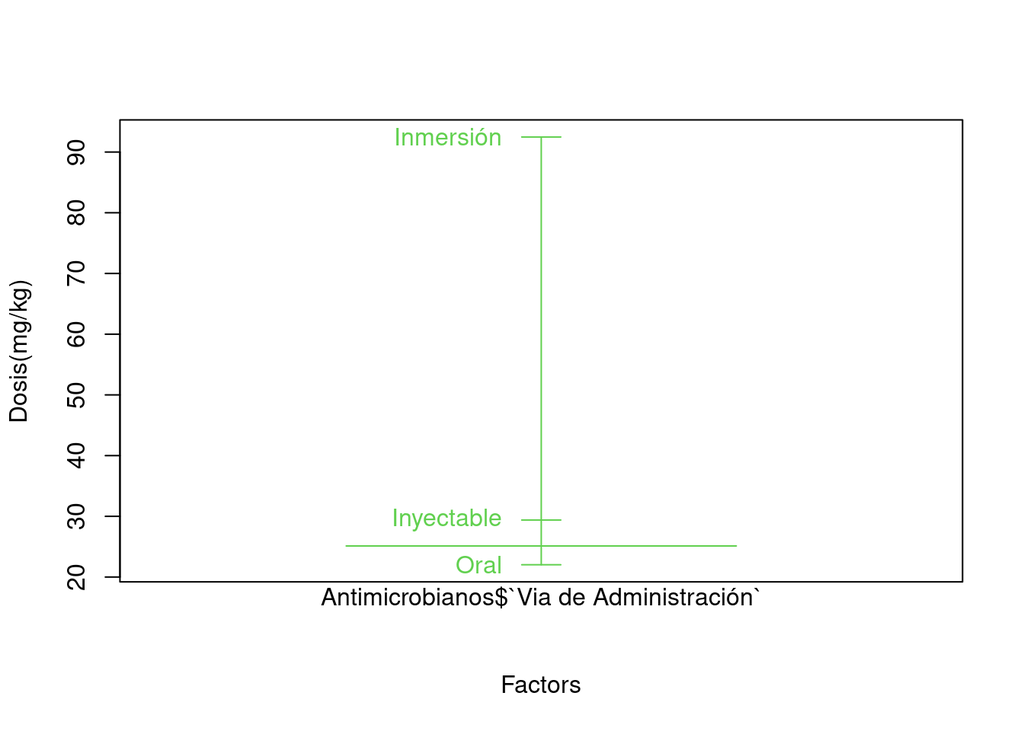

```r
plot.design(Antimicrobianos$Dosis ~ Antimicrobianos$`Via de Administración`, col=3,  ylab = "Dosis(mg/kg)")
```

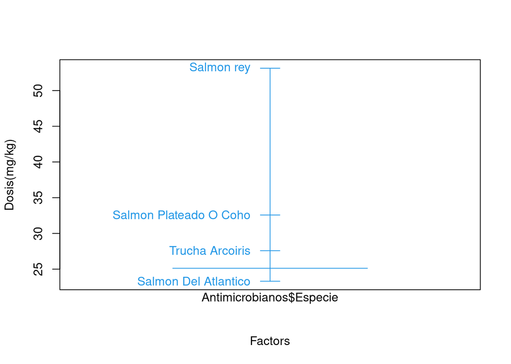

```r
plot.design(Antimicrobianos$Dosis ~ Antimicrobianos$Especie, col=4, ylab = "Dosis(mg/kg)")
```

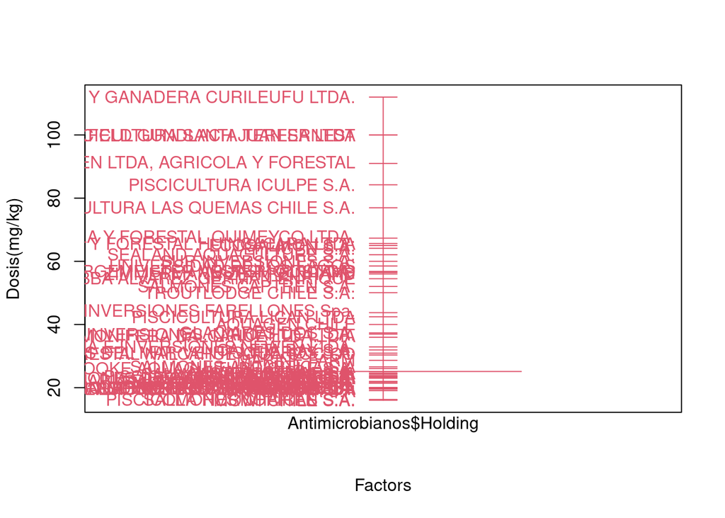

```r
plot.design(Antimicrobianos$Dosis~Antimicrobianos$Holding, col=2, ylab = "Dosis(mg/kg)")
```

```r
opts_chunk$set(warning = FALSE, message = FALSE)
```

- Observación N°1: la enfermedad es el factor que más desplaza la media de la dosis, en el caso de aeromona.

https://github.com/MVfvasqueze/Tarea_diplomado